# STATS 531 Midterm Project: Association between PM2.5 and temperature difference

Xiaoyue Liu UMID:28589009 xiaoyliu@umich.edu

March 6, 2016

**1. Experience of air quality and temperature difference**

- In the past 7 years, I was living in Beijing. There has been terrible air pollution since I went to university there. It was most serious from 2010 to 2012. We had to wear facial masks and reduce outdoor activities. Even with those protection, it is still a threat to health.Beijing began monitoring PM 2.5 levels in 2013 amid rising public concerns over pollution in the city.
- From my own experience, those days with a high pm2.5 seemed to have a smaller temperature difference within the day. In summer it brought stuffiness and in winter there seemed less wind.
- May there be relationship between pm2.5 and the temperature difference? We can analyse using time series methods.

**2. Data and fitted models**

**2.1 ARMA model with no transformation on data**

- We are going to look at historical data for Beijing, China. The PM2.5 data is collected from U.S. Department of State Air Quality Monitoring Program http://www.stateair.net/web/historical/1/1.html and the temperature data is collected from National Climite Data Center. The PM2.5 data is hourly collected, and the temperature data is daily collected, for convenience, I calculated the daily PM2.5 to compare to the temperature data.

```r
x <- read.csv(file="https://raw.githubusercontent.com/liuxiaoyue08/531documents/master/temp_pm25_2010_2012.csv",header=T)
head(x)
```

```
##         Time     pm2.5 TMAX TMIN  TD
## 1 2010-01-01 129.00000  -16 -102  86
## 2 2010-01-02 144.33333  -21  -63  42
## 3 2010-01-03  78.37500  -44  -99  55
## 4 2010-01-04  29.29167  -85 -134  49
## 5 2010-01-05  43.54167  -75 -156  81
## 6 2010-01-06  59.37500  -59 -167 108
```

- There are five variables in this processed dataset, Time, pm2.5, TMAX, TMIN and TD(for temperature difference) The we can code the pm2.5 and TD seperately.
- Write ${p_n^*}$ for PM2.5 in day $t_n=2010-01-01+n$.
- Write ${d_n^*}$ for temperature difference in day $t_n$.

```r
t <- x$Time
p <- x$pm2.5
d <- x$TD
```

- Let’s plot them first to get an intuitive feeling.

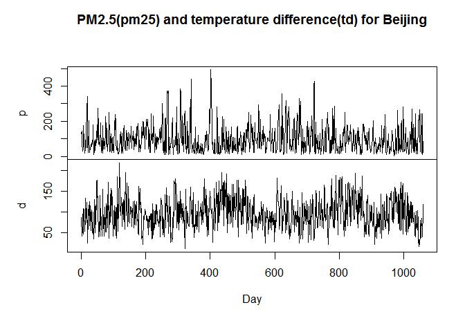

```r
plot(ts(cbind(p,d)),main = "PM2.5(pm25) and temperature difference(td) for Beijing",xlab="Day")
```

- Then let’s have a look at their spectrums. Here we choose the ‘ar’ method for smoothing.

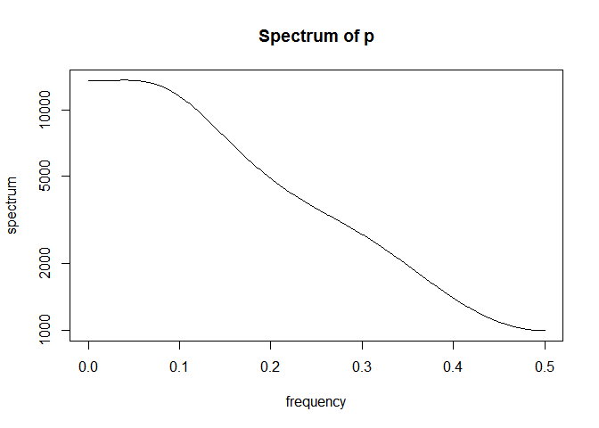

```r
spectrum(p,method='ar',main="Spectrum of p")
```

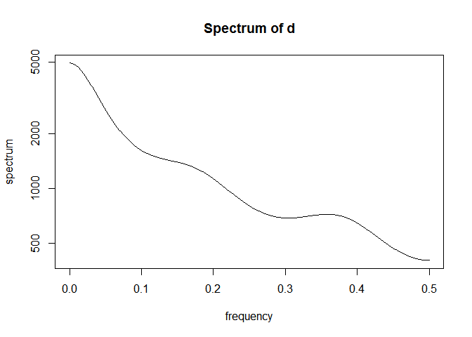

```r
spectrum(d,method='ar',main="Spectrum of d")
```

- From the spectrum plots we can see that there are some difference between those two time series. The temperature difference always respond to an AR process with one more parameter than the PM2.5.
- The temperature difference data can be fitted by an ARMA(2,1)(best small model) model, and the PM2.5 data can be fitted by an ARMA(1,1)(best small model) model.
- Then we want to investigate the relationship between temperature difference and PM2.5.
- For example, we can try to analyse $d_{1:N}$ using a regression with ARMA errors model, $d_n = \alpha + \beta p_n + \epsilon_n,$ where $\{\epsilon_n\}$ is a Gaussian ARMA process.
- An ARMA(4,3) model is suggested according to the AIC table, however, it is not stable with many parameters and there appear some inconsistencies around high orders in the AIC table.
- We noticed that a smaller model ARMA(2,1) is suggested by a relatively small AIC. We can try to fit the data with this ARMA(2,1) model.

```r
arima(d,order=c(2,0,1), xreg=p)
```

```
##
## Call:
## arima(x = d, order = c(2, 0, 1), xreg = p)
##
## Coefficients:
##          ar1      ar2      ma1  intercept        p
##       1.3275  -0.3445  -0.9335    99.9070  -0.0384
## s.e.  0.0367   0.0328   0.0201     4.0202   0.0152
##
## sigma^2 estimated as 998.2:  log likelihood = -5164.43,  aic = 10340.86
```

- The standard errors, computed from the observed Fisher information approximation, suggest a statistically significant association between cyclical variation in PM2.5 and temperature difference.
- We can also compute a p-value from a likelihood ratio test

```r
log_lik_ratio <- as.numeric(
   logLik(arima(d,xreg=p,order=c(2,0,1))) -
   logLik(arima(d,order=c(2,0,1)))
)
LRT_pval <- 1-pchisq(2*log_lik_ratio,df=1)
```

- This gives a p-value of 0.01198262
- There have been report that the PM2.5 related air pollution is more serious year by year. Let’s see what happend in 2012.

```r
p2012 <- p[706:1060]
d2012 <- d[706:1060]
t2012 <- as.Date(t[706:1060])
arima(d2012,c(2,0,1),xreg=p2012)
```

```
##
## Call:
## arima(x = d2012, order = c(2, 0, 1), xreg = p2012)
##
## Coefficients:
##          ar1      ar2      ma1  intercept    p2012
##       1.3374  -0.3551  -0.9214    99.9762  -0.0475
## s.e.  0.0622   0.0575   0.0305     7.7602   0.0288
##
## sigma^2 estimated as 1014:  log likelihood = -1732.6,  aic = 3477.21
```

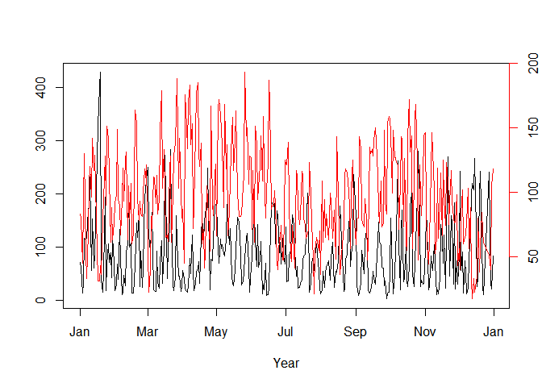

```r
plot(t2012,p2012,type="l",xlab="Year",ylab="")
par(new=TRUE)
plot(t2012,d2012,col="red",type="l",axes=FALSE,xlab="",ylab="")
axis(side=4, col="red")
```

**2.2 Analysis of temporal differences**

- Let’s take another approach using the daily changes in PM2.5, rather than PM2.5 itself. In this case, we consider the variable $\Delta {p_n^*} = {p_n^*} - {p_{n-1}^*}.$

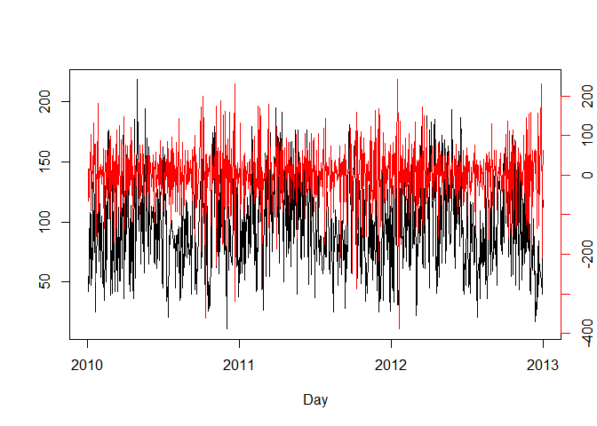

```r
delta_p <- p[2:1060] - x$pm2.5[as.numeric(x$Time) %in% (as.numeric(t)-1)]
t2 <- as.Date(t[2:1060])
d2 <- d[2:1060]
plot(t2,d2,type="l",xlab="Day",ylab="")
par(new=TRUE)
plot(t2,delta_p,col="red",type="l",axes=FALSE,xlab="",ylab="")
axis(side=4,col="red")
```

- In the plot, temperature difference is in black and with left axis, and differenced PM2.5 is in red and with right axis.
- The relationship seems more clear. We fit with an ARMA(2,1) model again (suggested by AIC).
- We can also compute a p-value from a likelihood ratio test

```r
log_lik_ratio <- as.numeric(
   logLik(arima(d2,xreg=delta_p,order=c(2,0,1))) -
   logLik(arima(d2,order=c(2,0,1)))
)
LRT_pval2 <- 1-pchisq(2*log_lik_ratio,df=1)
```

- This gives 0.001300795, more significant than the previous model.

```r
arima(d2,xreg=delta_p,order=c(2,0,1))
```

```
##
## Call:
## arima(x = d2, order = c(2, 0, 1), xreg = delta_p)
##
## Coefficients:
##          ar1      ar2      ma1  intercept  delta_p
##       1.3200  -0.3371  -0.9308    95.7360   0.0398
## s.e.  0.0375   0.0335   0.0207     3.8717   0.0124
##
## sigma^2 estimated as 995.1:  log likelihood = -5157.9,  aic = 10327.79
```

- This time the coefficient is positive.

**4. Some supplementary analysis**

**4.1 Model selection by AIC**

```r
low_aic_table <- aic_table(d,5,6,xreg=p)
require(knitr)
kable(low_aic_table,digits=2)
```

[output not shown]

```r
low_aic_table <- aic_table(d,5,6,xreg=delta_p)
require(knitr)
kable(low_aic_table,digits=2)
```

[output not shown]

- This suggests that the model with ARMA(2,1) is the best small model.
- There are some larger models with impressive AIC values. For example, let’s look at the fitted model with ARMA(4,3) errors.

```r
arima(d,xreg=p,order=c(4,0,3))
```

```
##
## Call:
## arima(x = d, order = c(4, 0, 3), xreg = p)
##
## Coefficients:
##          ar1     ar2      ar3      ar4     ma1      ma2      ma3
##       0.1860  0.9442  -0.0856  -0.0848  0.2190  -0.8632  -0.1981
## s.e.  0.8132  0.3350   0.6876   0.2340  0.8139   0.0432   0.7051
##       intercept        p
##         99.8480  -0.0401
## s.e.     4.0311   0.0152
##
## sigma^2 estimated as 991.7:  log likelihood = -5160.98,  aic = 10341.96
```

**4.2 Residual analysis**

- We should check the residuals for the fitted model, and look at their sample autocorrelation.

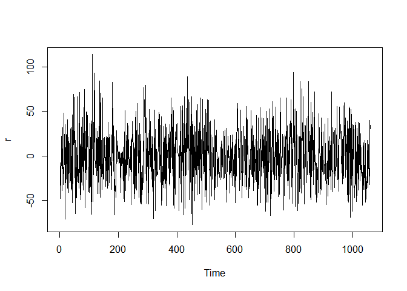

```r
r <- resid(arima(d,xreg=p,order=c(2,0,1)))
plot(r)
```

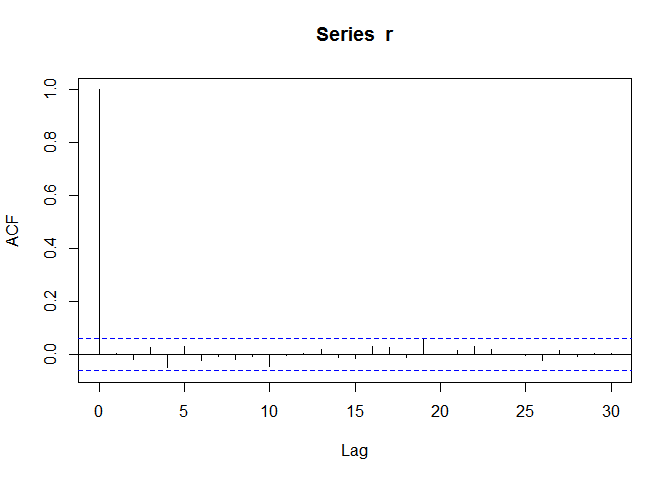

```r
acf(r)
```

**5. References**

The PM2.5 data is collected from U.S. Department of State Air Quality Monitoring Program http://www.stateair.net/web/historical/1/1.html The temperature data is collected from National Climite Data Center.